# Exercise 1.2

Joe Barry

February 20, 2021

### Question 1

First, we have to install our necessary library, and load the data.

```r
library("tswge")
data(ss08)
```

Here is the base plot from R:

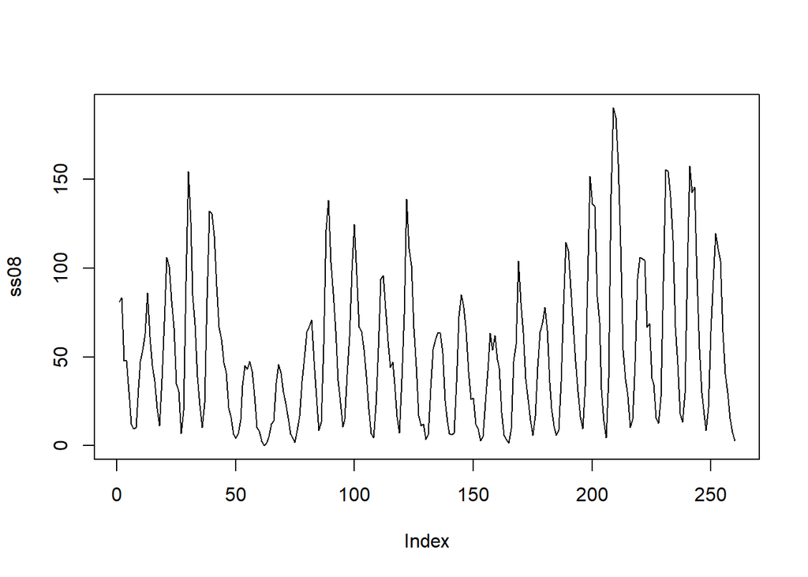

```r
plot(ss08, type = 'l')
```

And here is the plot using our textbook function:

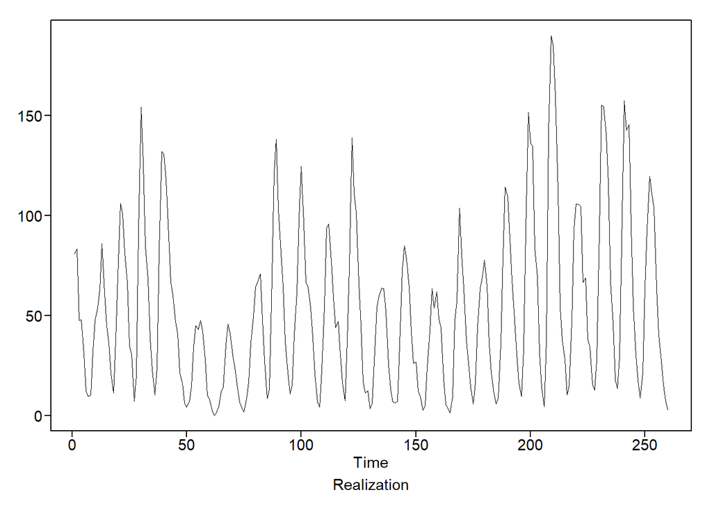

```r
plotts.wge(ss08)
```

### Question 2

```r
mean(ss08)
```

```
## [1] 52.24385
```

The mean of our data is $52.24385$.

### Question 3

Let's load Hadley.

```r
data(hadley)
```

Now, here are the plots.

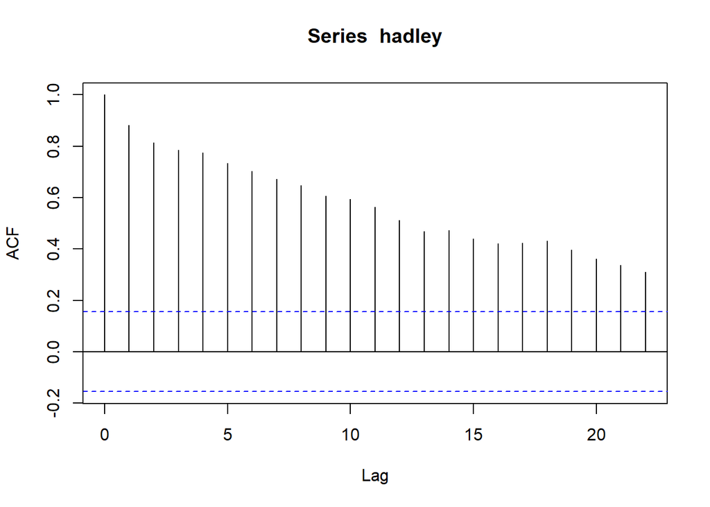

```r
acf(hadley, type = "correlation")
```

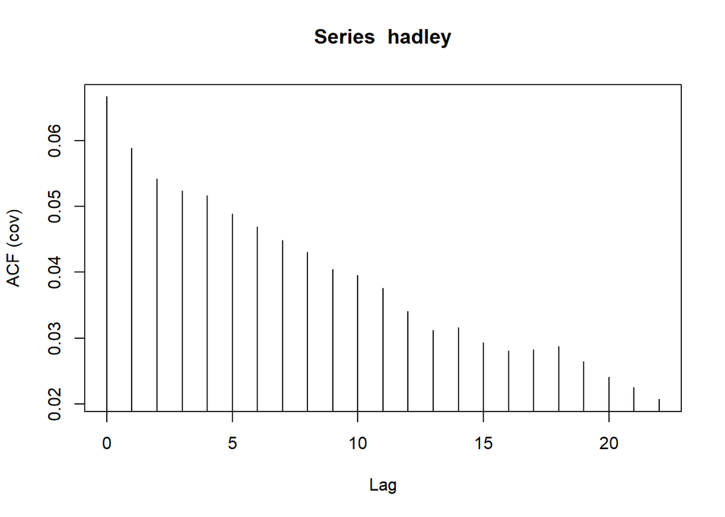

```r
acf(hadley, type = "covariance")
```

### Question 4

Here is our autocovariance for $h = 0$:
$$\hat \gamma_0 = \frac{1}{n} \sum_{t=1}^{n} (X_t - \mu) (X_{t} - \mu)$$

And for $h = 1$:
$$\hat \gamma_1 = \frac{1}{n} \sum_{t=1}^{n-1} (X_t - \mu) (X_{t + 1} - \mu)$$

Now, here is our autocorrelation function for $h = 0$:
$$\hat \rho_0 = \frac{\hat \gamma_0}{\hat \gamma_0}$$

Note that this will always be 1.

Lastly, autocorrelation for $h = 1$:
$$\hat \rho_1 = \frac{\hat \gamma_1}{\hat \gamma_0}$$

Now, to compute them, starting with autocorrelations $\rho_0$ and $\rho_1$:

```r
acf(hadley, lag.max = 1, plot = FALSE)
```

```
##
## Autocorrelations of series 'hadley', by lag
##
##     0     1
## 1.000 0.882
```

Now we've confirmed that $\hat \rho_0 = 1$ (as expected), and $\hat \rho_1 = .882$.

```r
acf(hadley, lag.max = 1, type = 'covariance', plot = FALSE)
```

```
##
## Autocovariances of series 'hadley', by lag
##
##      0      1
## 0.0667 0.0588
```

We've found that $\hat \gamma_0 = .0667$ and $\hat \gamma_1 = .0588$.

### Question 5

First, let's load and plot the data:

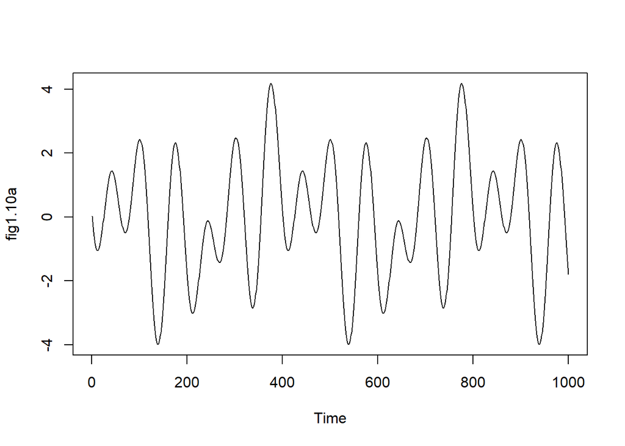

```r
data(fig1.10a)
plot.ts(fig1.10a)
```

And now the periodogram, which we will need to extend the range of to plot them all:

```r
period.wge(fig1.10a, dbcalc = T, plot = TRUE)
```

[output not shown]

[output cut: 114 more lines]

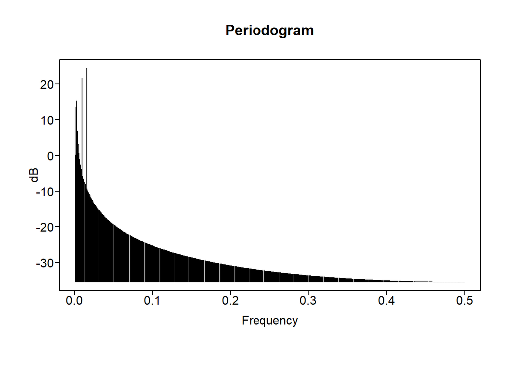

```r
period <- period.wge(fig1.10a, dbcalc = T, plot = TRUE)
```

We can see the three frequencies in this graph, but we can isolate the specific values.

```r
which.max(period$pgram)
```

```
## [1] 15
```

```r
period$freq[15]
```

```
## [1] 0.015
```

Our first frequency is .015. We can find the next two by indexing for the values smaller than this, as we can see that the largest is the last of our peaks.

```r
which.max(period$pgram[0:14])
```

```
## [1] 10
```

```r
period$freq[10]
```

```
## [1] 0.01
```

```r
which.max(period$pgram[0:9])
```

```
## [1] 3
```

```r
period$freq[3]
```

```
## [1] 0.003
```

So our principal frequencies are $f = [.003, .01, .015]$.

Put into the equation given, we have:
$$X(t) = \cos(2\pi .003 t ) + 1.5 \cos(2\pi .01 t + 1) + 2 \cos(2 \pi .015 t + 2.5)$$

Put into code; accounting for the times being cut into tenths:

```r
t <- 0:1000/10
Xt <- cos(2*pi*.03*t) + 1.5*cos(2*pi*.1*t + 1) + 2*cos(2*pi*.15*t + 2.5)
```

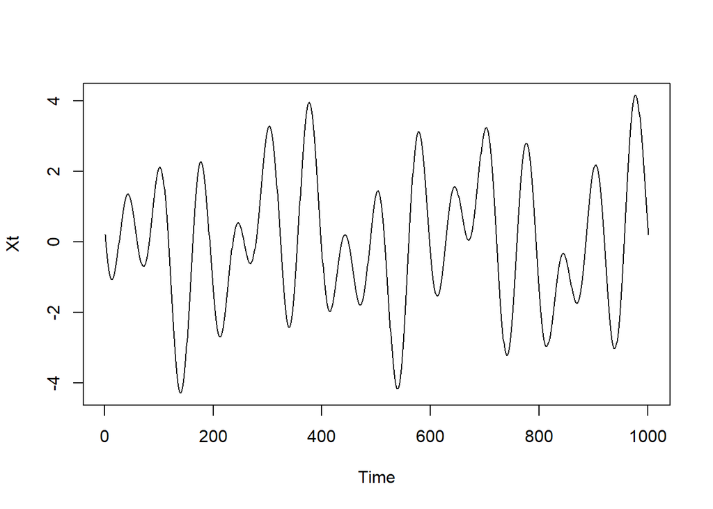

```r
plot.ts(Xt)
```